# Programming

“3. Control Structures”

“Wen-Bin Chuang”

“2024/07/25”

# Today’s Topics

- Decision-Making – IF, IF Else, If Elif Else
- Repeating Actions – While Loop and For Loop

# Introduction

They allow for **decision-making** and **repeating actions**, which are fundamental in creating dynamic and responsive programs.

# Decision Structures

The program always needs to be executed depending upon a particular condition. Python provides the following statements for implementing the decision structure.

- if statement
- if else statement
- if-elif-else Statement
- nested if statement

## if statement

If the *condition (Boolean expressions) is true*, statement is executed; otherwise it is **skipped**.

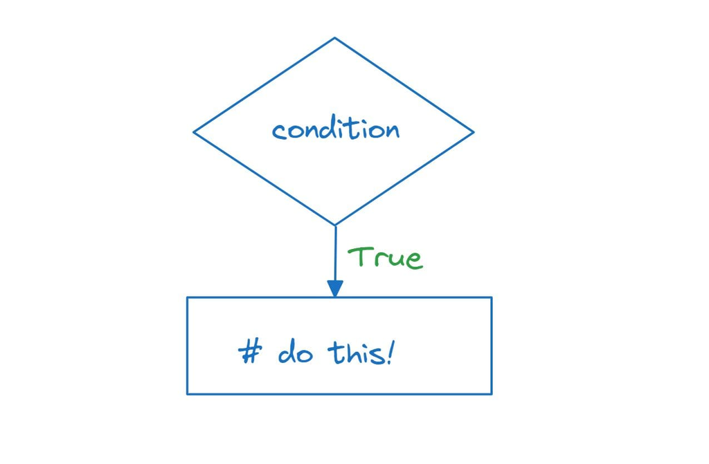

```python
#This program illustrates if statement.
number = int(input("Enter a number:"))

if number < 0:
    number =  - number

print("The absolute value of number is", number)
```

## if-else Statement

The *condition* is evaluated first. If the condition is true, statement1 is executed. If the condition is false, statement 2 is executed.

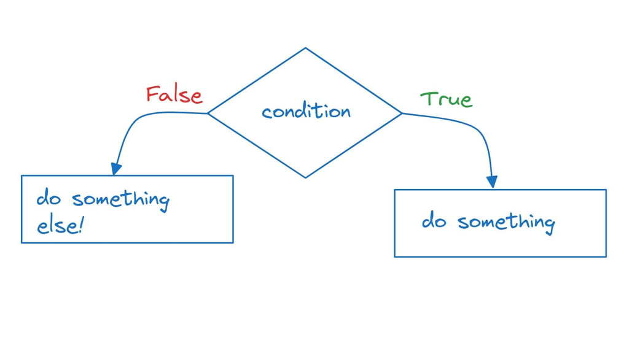

```python
# This program test a number is even or odd.
number = int(input('Enter number: '))

if number%2 == 0:
    print(number, 'is even.')
else:
    print(number, 'is odd.')
```

## if-elif-else Statement

The **if-elif-else** statement is used when you have **multiple conditions** to check. It allows you to test multiple conditions and execute the corresponding block of code for the first true condition encountered. If the conditions in the *if* and all *elif* statements evaluate to false, the `else` block is executed.

*elif* is an abbreviation of “else if.” Again, exactly one branch will be executed. There is no limit of the number of elif statements, but the last branch has to be an else statement.

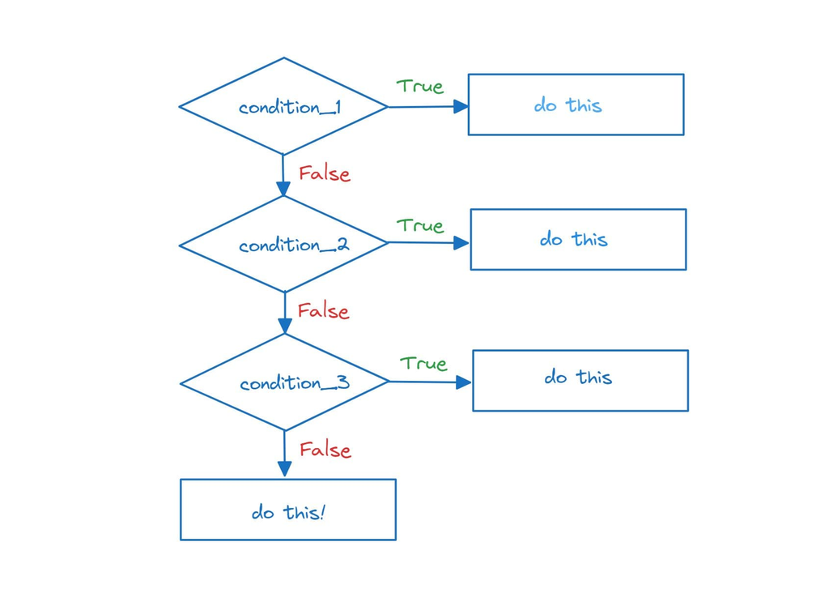

```python
# This program determines greater number.
x = int(input("Enter first number:"))
y = int(input("Enter second number:"))

if x < y:
    print (x, "is less than", y)
elif x > y:
    print (x, "is greater than", y)
else:
    print (x, "and", y, "are equal")
```

## Nested Decision Structures

```python
# This program determines greater number.
x = int(input("Enter first number:"))
y = int(input("Enter second number:"))

if x == y:
    print (x, "and", y, "are equal")
else:
    if x < y:
        print (x, "is less than", y)
    else:
        print (x, "is greater than", y)
```

# Logical Operators in Condition Tests

## 1. “and” Operator

It returns True if **all the conditions are true**. Otherwise, it returns False.

```python
# Checking Age and Salary for Loan Eligibility
age = 25
salary = 50000

if age >= 18 and salary >= 30000:
    print("You are eligible for a loan.")
else:
    print("You are not eligible for a loan.")
```

## 2. “or” Operator

It returns True if at least one of the conditions is true, and False if all the conditions are false.

```python
# Checking if a Student has Passed in at Least One Subject
subject1 = 70
subject2 = 55

if subject1 >= 50 or subject2 >= 50:
    print("The student has passed in at least one subject.")
else:
    print("The student has failed in all subjects.")
```

## 3. “not” Operator

It returns True if the condition is false, and False if the condition is true.

```python
answer = 17
if answer != 42:
    print("That is not the correct answer. Please try again!")
```